# Resolução-da-Lista-1-de-ADAR

Maicon Fonseca Andrades

02/12/2020

##### 1. Execute as seguintes expressões no R mostrando os resultados obtidos.

```r
(var1 <- 1 + 1)
```

```
## [1] 2
```

```r
(var2 <- 100:130)
```

```
##  [1] 100 101 102 103 104 105 106 107 108 109 110 111 112 113 114 115 116 117 118
## [20] 119 120 121 122 123 124 125 126 127 128 129 130
```

```r
(var3 <- 5 - +1)
```

```
## [1] 4
```

```r
(var4 <- 3 %% 5)
```

```
## [1] 3
```

```r
(var5 <- 2 * 3)
```

```
## [1] 6
```

```r
(var6 <- 4 - 1)
```

```
## [1] 3
```

```r
(var7 <- 6 / (4 - 1))
```

```
## [1] 2
```

##### 2. Utilize uma expressão para cada item.

1. Escolha um número e some 3 a ele.
2. Multiplique o resultado por 2.
3. Subtraia 10 da resposta.
4. Divida o que foi obtido por 4.

```r
(var8 <- 3 + 3) # número escolhido + 3
```

```
## [1] 6
```

```r
(var9 <- 2 * var8) # resposta letra b
```

```
## [1] 12
```

```r
(var10 <- var9 - 10) # resposta letra c
```

```
## [1] 2
```

```r
(var11 <- var10 / 4) # resposta letra d
```

```
## [1] 0.5
```

##### 3. Calcule $\sqrt{16}$, $16^{{0.5}^3}$, $(16^{0.5})^3$ e $4^\frac{3}{2}$.

```r
(raiz <- sqrt(16))
```

```
## [1] 4
```

```r
(pot1 <- (16)^(0.5^3))
```

```
## [1] 1.414214
```

```r
(pot2 <- (16^0.5)^3)
```

```
## [1] 64
```

```r
(pot3 <- 4^(3 / 2))
```

```
## [1] 8
```

##### 4. Teste as expressões `log10(1000)`, `log(1000)`, `exp(log(1000))`. Verifique se você entendeu as diferentes funções logarítmicas.

```r
(log_ex1 <- log10(1000)) #log de x = 1000 na base 10
```

```
## [1] 3
```

```r
(log_ex2 <- log(1000)) # log de x = 1000 na base = exp(1)
```

```
## [1] 6.907755
```

```r
(log_ex3 <- exp(log(1000))) # log de uma exponencial
```

```
## [1] 1000
```

```r
(log_ex4 <- log2(64)) # log de x = 64 na base 2
```

```
## [1] 6
```

##### 5. Defina as variáveis abaixo tomando cuidados ao nomear as variáveis, conforme visto em sala de aula. Mostre os valores para as seguintes constantes:

```r
(vel_luz <- 2.988 * 10^{8})
```

```
## [1] 298800000
```

2. Carga elementar ou eletrônica: $e~=~1.602~\mathrm{x}~10^{-19} \left [ C \right ]$

```r
(e <- 1.602 * 10^{-19})
```

```
## [1] 1.602e-19
```

3. Permissividade do vácuo: $\epsilon_{0}~=~8.85~\mathrm{x}~10^{-12}~\left [ C^{2}N^{-1}m^{2} \right ]$

```r
e_0 <- 8.85 * 10^{-12}
```

4. Constante de Planck: $h~=~6.626~\mathrm{x}~10^{-34}~\left [ Js\right]$

```r
planck <- 6.626 * 10^{-34}
```

5. Constante de Stefan Boltzman: $\sigma~=~5.67~\mathrm{x}~10^{-8}~\left [Wm^{-2}K{-4}\right]$

```r
boltz <- 5.67 * 10^{-8}
```

6. Constante solar: $S_0~=~1380~\left [ Wm^{-2} \right ]$

```r
(S_0 <- 1380)
```

```
## [1] 1380
```

7. Constante de Avogadro: $N_A~=~6.022~\mathrm{x}~10^{23}\left [mol^{-1}\right ]$

```r
cte_avog <- 6.022 * 10^{23}
```

8. Constante dos gases para o ar seco: $R_d~=~287.04~[JK^{-1}kg^{-1}$

```r
R_ars <- 287.04
```

1. Constante dos gases ideais para vapor: $R_w~=~461.5~[JK^{-1}kg^{-1}$

```r
R_vap <- 461.5
```

10. Densidade do ar seco para CNTP (à 0°C em 1000 mb):  
    $\rho~=~1.2754~[kgm^{-3}]$

```r
rho_ars <- 1.2754
```

11. Pressão média ao nível médio do mar para atmosfera padrão: $P_0~=~1013.25~[mb]$

```r
p_0 <- 1013.25
```

12. Temperatura ao nível médio do mar para atmosfera padrão: $T_0~=~288.15~[K]$

```r
T_0 <- 288.15
```

13. Calor latente de vaporização ou condensação (à 0 °C): $\lambda_v~=~2.501\mathrm{x}10^{6}~[Jkg^{-1}]$

```r
heat_lvap <- 2.501 * 10^6
```

14. Calor latente de fusão (à 0 °C): $\lambda_f~=~0.334\mathrm{x}10^{6}~[Jkg^{-1}]$

```r
heat_lfus <- 0.334 * 10^6
```

```r
M_h2o <- 28.96
```

16. Peso molecular do ar: $M_{ar}~=~28.96\left [g~mol^{-1} \right ]$

```r
M_ar <- 28.96
```

17. Raio da terra: $r~=~6.37~\mathrm{x}~10^{6}\left [ m \right ]$

```r
R0 <- 6.37 * 10^{6}
```

18. Velocidade angular da Terra: $\Omega~=~7.29~\mathrm{x}~10^{-5}~\left [rad~s^{-1} \right ]$

```r
vel_ang_Ter <- 7.29 * 10^{-5}
```

##### 6. a. Como você pode fazer para que a constante $pi$ seja mostrada com 20 dígitos? (b) Como voltar a trabalhar a com 7 dígitos novamente? c. Mostre o número neperiano com 7 dígitos.

1. Para mostrar a constante $pi$ com 20 dígitos basta escrever:

```r
options(digits = 20)
(pi)
```

```
## [1] 3.141592653589793116
```

2. Para voltar a trabalhar com 7 dígitos, basta alterar o número no no argumento entre parênteses:

```r
options(digits = 7)
(pi)
```

```
## [1] 3.141593
```

3. Número neperiano com 7 dígitos:

```r
options(digits = 7)
(exp(1))
```

```
## [1] 2.718282
```

##### 7. Determine a temperatura de bulbo úmido ($T_w$) usando a expressão empírica (Stull, 2011) abaixo. Salve os resultados em variáveis diferentes. Determine a $T_w$ para temperatura do ar $T~=~20~°C$ e Umidade relativa $UR~=~70~\%$ ? Defina variáveis para os valores de $T$ e $UR$ solicitados e substitua-os na equação de $T_w$. Não é necessária a conversão dos dados expressos em % para aplicação na equação.

$$T_w~=~T*atan[0.151977*(UR+8.313659)^{1/2}]~+
~\\atan(T+UR)-\\atan(UR-1.676331)+\\0.00391838(UR)^{3/2}*atan(0.023101*UR)-
4.686035$$

```r
Temp <- 20
um_rel <- 70

T_w <- Temp * atan(0.151977 * (um_rel + 8.313659)^{
  1 / 2
}) +
  atan(Temp + um_rel) -
  atan(um_rel - 1.676331) +
  0.00391838 * (um_rel)^{
    3 / 2
  } * atan(0.023101 * um_rel) -
  4.686035

options(digits = 7)
(T_w)
```

```
## [1] 16.28012
```

##### 8. Determine os valores de umidade do solo:

- no potencial hídrico de 10kPa ($\theta_{10kPa}$)
- na capacidade de campo ($\theta_{33kPa}$)
- no ponto de murcha permanente ($\theta_{1500kPa}$)

utilizando o conjunto de equações de pedotransferência abaixo (> Tomasela et al. 2003):

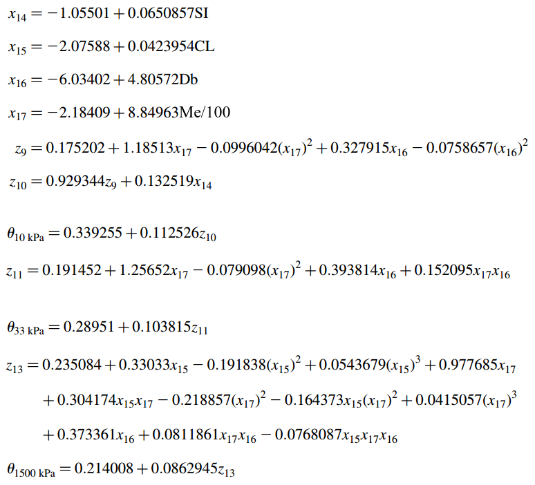

```r
knitr::include_graphics("conj-eqs-tomasella2003.png")
```

```r
si <- 16.29
cl <- 49.25
db <- 1.25
me <- 25

x14 <- -1.05501 + 0.0650857 * si

x15 <- -2.07588 + 0.0423954 * cl

x16 <- -6.03402 + 4.80572 * db

x17 <- -2.18409 + 8.84963 * me / 100

z9 <- 0.175202 + 1.18513 * x17 - 0.0996042 * (x17^2) + 0.327915 * x16 -
  0.0758657 * (x16^2)

z10 <- 0.929344 * z9 + 0.132519 * x14

theta10 <- 0.339255 + 0.112526 * z10

z11 <- 0.191452 + 1.25652 * x17 - 0.079098 * (x17^2) + 0.393814 * x16 +
  0.152095 * x17 * x16

theta33 <- 0.28951 + 0.103815 * z11

z13 <- 0.235084 + 0.33033 * x15 - 0.191838 * (x15^2) + 0.0543679 * (x15^3) +
  0.977685 * x17 + 0.304174 * x15 * x17 - 0.218857 * (x17^2) -
  0.164373 * x15 * (x17^2) +
  0.0415057 * (x17^3) + 0.373361 * x16 + 0.0811861 * x17 * x16 -
  0.0768087 * x15 * x17 * x16

theta1500 <- 0.214008 + 0.0862945 * z13

# Umidade do solo no potencial hídrico de 10kPa
print(theta10)
```

```
## [1] 0.3602289
```

```r
# Umidade do solo na capacidade de campo
print(theta33)
```

```
## [1] 0.3119623
```

```r
# Umidade do solo no ponto de murcha permanente
print(theta1500)
```

```
## [1] 0.2361487
```

##### 9. Arredonde para 2 casas decimais os resultados da questão 8. Dica ver `?round`.

```r
# theta10
(theta10 <- round(theta10, 2))
```

```
## [1] 0.36
```

```r
# theta33
(theta33 <- round(theta33, 2))
```

```
## [1] 0.31
```

```r
# theta1500
(theta1500 <- round(theta1500, 2))
```

```
## [1] 0.24
```